# The Lady Tasting Tea

Phil Henrickson

2023-05-12

Ronald Fisher famously discussed his experiment to figure out whether a woman (statistican Debabrata Basu) was capable of discerning whether milk or tea had been poured first in a cup of tea. That is, given a cup of tea, she claimed she could correctly identify whether the tea had been poured before the milk, or whether milk had been poured before the tea.

Fisher decided to test this using an experiment with eight cups of tea. Four of them would have the milk poured first; the other four would have the tea poured first. She knew this number in advance, and her challenge was to correctly identify the eight cups.

We can illustrate the experiment with some simple code. First, we randomly generate the actual sequence of cups.

```r
# lady tasting tea example
# number of cups to be tested
n_cups <- 8

# actual sequence of cups
set.seed(32)
truth <- sample(rep(c("milk", "tea"), each = n_cups / 2))

truth
```

```
## [1] "tea"  "tea"  "milk" "milk" "milk" "tea"  "milk" "tea"
```

The lady would have to taste eight cups and generate her own sequence. A random guess might look something like this.

```r
set.seed(2)
guess <- sample(rep(c("milk", "tea"), each = n_cups / 2))

guess
```

```
## [1] "tea"  "tea"  "tea"  "milk" "tea"  "milk" "milk" "milk"
```

How many would be correct from this random guess?

```r
# how many right?
sum(truth == guess)
```

```
## [1] 4
```

Random will pretty often get 4 of the cups correct. How many did she need to get correct in order to prove to Fisher that she could tell the difference?

Or, another way to think about this, how often would we expect someone random guessing to correctly get 2, 4, 6, 8 cups correct?

We could estimate this via simple simulation: simulate 1000 guesses randomly and see how many are correct. We can then plot the distribution of those simulations, and count the number of times we observed each number.

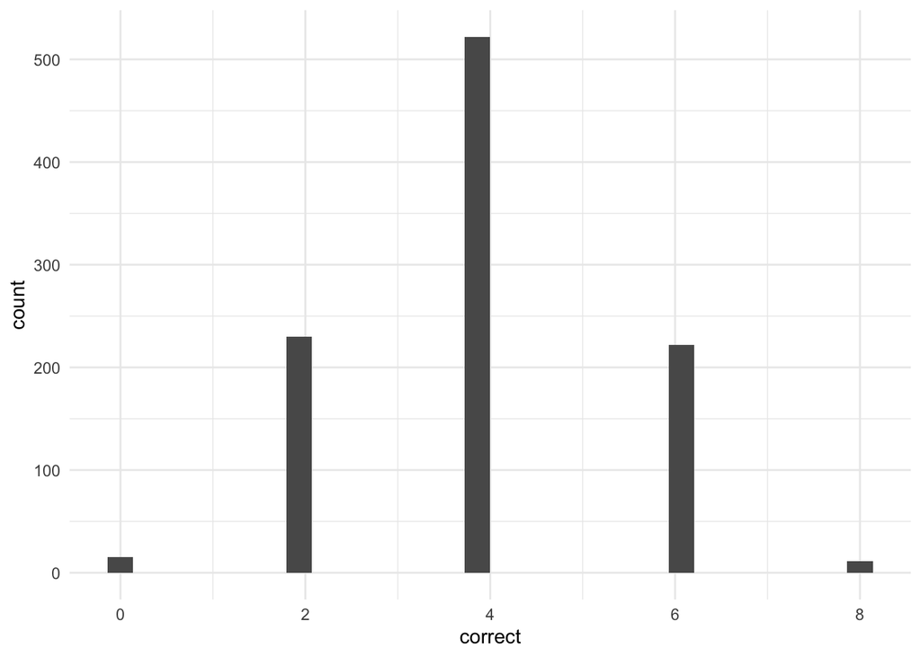

```r
# function to implement this in one step
sim_guess <- function(n_cups){

        # simulate true sequence
        truth = sample(rep(c("milk", "tea"), each = n_cups / 2))

        # a guess
        guess <- sample(rep(c("milk", "tea"), each = n_cups / 2))

        # how many correct
        sum(truth == guess)

}

n = 1000

set.seed(1)
sims = replicate(n,
          sim_guess(8))

# histogram
sims %>%
        tibble(correct = .) %>%
        ggplot(aes(x=correct))+
        geom_histogram(bins = 30)+
        theme_minimal()
```

```r
# table
sims %>%
        tibble(correct = .)  %>%
        group_by(correct) %>%
        count() %>%
        ungroup() %>%
        mutate(prop = n / sum(n))
```

```
## # A tibble: 5 × 3
##   correct     n  prop
##     <int> <int> <dbl>
## 1       0    15 0.015
## 2       2   230 0.23
## 3       4   522 0.522
## 4       6   222 0.222
## 5       8    11 0.011
```

In 1000 simulations, random guessing only produced all eight correct 11/1000, or 0.011 of the time. Random guessing got six cups correct 222/1000, or 0.222 of the time. This means that even if someone had no idea of the difference between the milk and tea, roughly 1 in 5 times we would expect them to get 6/8 right.

We got these results from random simulation, but we can calculate the exact probability by looking at all possible sequences of eight cups in which four are milk and four are tea. Turns out that there are 70 such combinations, which we can get either from using a formula for combinations $\frac{8!}{4!(8-4)!}$ or by just simulating all permutations and filtering to those with equal milk and tea.

```r
library(gtools)

# all possible permutations
all_perms = permutations(2, 8, c("milk", "tea"), repeats.allowed = T)

# now get only those where there are 4 milks and 4 teas, there should be 70 sequences
sequences = all_perms[apply(all_perms == 'milk', 1, sum) == 4,]

# now shuffle these in a random order
set.seed(2)
shuffled = sequences[sample(nrow(sequences)),]
```

This is all 70 sequences.

| tea tea tea tea milk milk milk milk | milk tea milk milk tea tea milk tea |
| --- | --- |
| milk milk tea milk milk tea tea tea | tea tea milk milk tea tea milk milk |
| milk tea tea tea milk milk milk tea | milk tea tea tea milk tea milk milk |
| milk milk tea milk tea tea milk tea | tea tea milk tea milk milk milk tea |
| milk tea milk milk tea milk tea tea | milk tea milk tea tea milk milk tea |
| tea milk milk tea milk tea milk tea | tea tea milk milk milk tea milk tea |
| tea milk tea milk tea milk tea milk | tea milk milk tea tea tea milk milk |
| milk milk tea tea milk tea milk tea | milk milk tea tea tea milk milk tea |
| milk milk milk milk tea tea tea tea | milk milk tea tea tea tea milk milk |
| milk milk milk tea tea milk tea tea | tea tea milk milk milk tea tea milk |
| tea milk tea tea milk tea milk milk | milk tea tea tea tea milk milk milk |
| milk tea milk milk milk tea tea tea | tea milk tea tea milk milk tea milk |
| tea tea tea milk milk tea milk milk | milk milk milk tea tea tea milk tea |
| tea tea milk tea milk tea milk milk | milk tea tea milk milk tea tea milk |
| tea milk tea milk tea tea milk milk | milk milk milk tea tea tea tea milk |
| tea milk tea tea tea milk milk milk | tea milk tea milk tea milk milk tea |
| tea tea tea milk milk milk tea milk | milk tea milk tea milk tea tea milk |
| tea milk milk milk tea tea tea milk | milk milk tea milk tea milk tea tea |
| milk tea tea tea milk milk tea milk | tea milk tea milk milk tea milk tea |
| tea tea milk tea tea milk milk milk | milk tea tea milk milk tea milk tea |
| tea milk tea milk milk tea tea milk | milk milk tea tea milk tea tea milk |
| tea milk milk milk milk tea tea tea | milk tea tea milk tea tea milk milk |
| tea milk milk tea tea milk milk tea | tea milk milk milk tea milk tea tea |
| tea milk milk milk tea tea milk tea | milk milk tea tea tea milk tea milk |
| tea tea milk milk milk milk tea tea | milk tea tea milk tea milk milk tea |
| tea milk milk tea milk milk tea tea | milk milk tea tea milk milk tea tea |
| tea tea milk milk tea milk milk tea | milk tea milk tea milk milk tea tea |
| tea milk milk tea tea milk tea milk | tea tea tea milk milk milk milk tea |
| tea tea tea milk tea milk milk milk | milk tea milk tea tea milk tea milk |
| milk tea milk milk tea tea tea milk | tea milk tea tea milk milk milk tea |
| milk milk tea milk tea tea tea milk | milk tea milk tea milk tea milk tea |
| tea tea milk milk tea milk tea milk | milk tea milk tea tea tea milk milk |
| tea milk milk tea milk tea tea milk | tea tea milk tea milk milk tea milk |
| milk tea tea milk tea milk tea milk | milk tea tea milk milk milk tea tea |
| milk milk milk tea milk tea tea tea | tea milk tea milk milk milk tea tea |

Remember, we originally generated the “true” sequence that the lady would have to guess. There is only one true sequence, and 70 possible sequences, so her probability of going 8/8 is 1/70, or 0.0142857.

| tea tea tea tea milk milk milk milk | milk tea milk milk tea tea milk tea |
| --- | --- |
| milk milk tea milk milk tea tea tea | tea tea milk milk tea tea milk milk |
| milk tea tea tea milk milk milk tea | milk tea tea tea milk tea milk milk |
| milk milk tea milk tea tea milk tea | tea tea milk tea milk milk milk tea |
| milk tea milk milk tea milk tea tea | milk tea milk tea tea milk milk tea |
| tea milk milk tea milk tea milk tea | tea tea milk milk milk tea milk tea |
| tea milk tea milk tea milk tea milk | tea milk milk tea tea tea milk milk |
| milk milk tea tea milk tea milk tea | milk milk tea tea tea milk milk tea |
| milk milk milk milk tea tea tea tea | milk milk tea tea tea tea milk milk |
| milk milk milk tea tea milk tea tea | tea tea milk milk milk tea tea milk |
| tea milk tea tea milk tea milk milk | milk tea tea tea tea milk milk milk |
| milk tea milk milk milk tea tea tea | tea milk tea tea milk milk tea milk |
| tea tea tea milk milk tea milk milk | milk milk milk tea tea tea milk tea |
| tea tea milk tea milk tea milk milk | milk tea tea milk milk tea tea milk |
| tea milk tea milk tea tea milk milk | milk milk milk tea tea tea tea milk |
| tea milk tea tea tea milk milk milk | tea milk tea milk tea milk milk tea |
| tea tea tea milk milk milk tea milk | milk tea milk tea milk tea tea milk |
| tea milk milk milk tea tea tea milk | milk milk tea milk tea milk tea tea |
| milk tea tea tea milk milk tea milk | tea milk tea milk milk tea milk tea |
| tea tea milk tea tea milk milk milk | milk tea tea milk milk tea milk tea |
| tea milk tea milk milk tea tea milk | milk milk tea tea milk tea tea milk |
| tea milk milk milk milk tea tea tea | milk tea tea milk tea tea milk milk |
| tea milk milk tea tea milk milk tea | tea milk milk milk tea milk tea tea |
| tea milk milk milk tea tea milk tea | milk milk tea tea tea milk tea milk |
| tea tea milk milk milk milk tea tea | milk tea tea milk tea milk milk tea |
| tea milk milk tea milk milk tea tea | milk milk tea tea milk milk tea tea |
| tea tea milk milk tea milk milk tea | milk tea milk tea milk milk tea tea |
| tea milk milk tea tea milk tea milk | tea tea tea milk milk milk milk tea |
| tea tea tea milk tea milk milk milk | milk tea milk tea tea milk tea milk |
| milk tea milk milk tea tea tea milk | tea milk tea tea milk milk milk tea |
| milk milk tea milk tea tea tea milk | milk tea milk tea milk tea milk tea |
| tea tea milk milk tea milk tea milk | milk tea milk tea tea tea milk milk |
| tea milk milk tea milk tea tea milk | tea tea milk tea milk milk tea milk |
| milk tea tea milk tea milk tea milk | milk tea tea milk milk milk tea tea |
| milk milk milk tea milk tea tea tea | tea milk tea milk milk milk tea tea |

What’s her probability of getting 2, 4, 6, 8 correct? We can calculate it as before.

```r
# now compare to our true sequence: cups
correct = apply(shuffled, 1, function(x) truth == x)

# how many times do we observe each correct?
sums = apply(correct, 2, sum)

# examine
sums %>%
        tibble(correct = .) %>%
        group_by(correct) %>%
        count() %>%
        ungroup() %>%
        mutate(prop = n / sum(n)) %>%
        mutate_if(is.numeric, round, 3)
```

```
## # A tibble: 5 × 3
##   correct     n  prop
##     <dbl> <dbl> <dbl>
## 1       0     1 0.014
## 2       2    16 0.229
## 3       4    36 0.514
## 4       6    16 0.229
## 5       8     1 0.014
```

Which we can see by just highlighting the sequences. This is highlighting (in dark grey) the addiitional sequences with at least six correct.

| tea tea tea tea milk milk milk milk | milk tea milk milk tea tea milk tea |
| --- | --- |
| milk milk tea milk milk tea tea tea | tea tea milk milk tea tea milk milk |
| milk tea tea tea milk milk milk tea | milk tea tea tea milk tea milk milk |
| milk milk tea milk tea tea milk tea | tea tea milk tea milk milk milk tea |
| milk tea milk milk tea milk tea tea | milk tea milk tea tea milk milk tea |
| tea milk milk tea milk tea milk tea | tea tea milk milk milk tea milk tea |
| tea milk tea milk tea milk tea milk | tea milk milk tea tea tea milk milk |
| milk milk tea tea milk tea milk tea | milk milk tea tea tea milk milk tea |
| milk milk milk milk tea tea tea tea | milk milk tea tea tea tea milk milk |
| milk milk milk tea tea milk tea tea | tea tea milk milk milk tea tea milk |
| tea milk tea tea milk tea milk milk | milk tea tea tea tea milk milk milk |
| milk tea milk milk milk tea tea tea | tea milk tea tea milk milk tea milk |
| tea tea tea milk milk tea milk milk | milk milk milk tea tea tea milk tea |
| tea tea milk tea milk tea milk milk | milk tea tea milk milk tea tea milk |
| tea milk tea milk tea tea milk milk | milk milk milk tea tea tea tea milk |
| tea milk tea tea tea milk milk milk | tea milk tea milk tea milk milk tea |
| tea tea tea milk milk milk tea milk | milk tea milk tea milk tea tea milk |
| tea milk milk milk tea tea tea milk | milk milk tea milk tea milk tea tea |
| milk tea tea tea milk milk tea milk | tea milk tea milk milk tea milk tea |
| tea tea milk tea tea milk milk milk | milk tea tea milk milk tea milk tea |
| tea milk tea milk milk tea tea milk | milk milk tea tea milk tea tea milk |
| tea milk milk milk milk tea tea tea | milk tea tea milk tea tea milk milk |
| tea milk milk tea tea milk milk tea | tea milk milk milk tea milk tea tea |
| tea milk milk milk tea tea milk tea | milk milk tea tea tea milk tea milk |
| tea tea milk milk milk milk tea tea | milk tea tea milk tea milk milk tea |
| tea milk milk tea milk milk tea tea | milk milk tea tea milk milk tea tea |
| tea tea milk milk tea milk milk tea | milk tea milk tea milk milk tea tea |
| tea milk milk tea tea milk tea milk | tea tea tea milk milk milk milk tea |
| tea tea tea milk tea milk milk milk | milk tea milk tea tea milk tea milk |
| milk tea milk milk tea tea tea milk | tea milk tea tea milk milk milk tea |
| milk milk tea milk tea tea tea milk | milk tea milk tea milk tea milk tea |
| tea tea milk milk tea milk tea milk | milk tea milk tea tea tea milk milk |
| tea milk milk tea milk tea tea milk | tea tea milk tea milk milk tea milk |
| milk tea tea milk tea milk tea milk | milk tea tea milk milk milk tea tea |
| milk milk milk tea milk tea tea tea | tea milk tea milk milk milk tea tea |

This is highlighting the additional sequences (in light grey) that had at least four correct.

| tea tea tea tea milk milk milk milk | milk tea milk milk tea tea milk tea |
| --- | --- |
| milk milk tea milk milk tea tea tea | tea tea milk milk tea tea milk milk |
| milk tea tea tea milk milk milk tea | milk tea tea tea milk tea milk milk |
| milk milk tea milk tea tea milk tea | tea tea milk tea milk milk milk tea |
| milk tea milk milk tea milk tea tea | milk tea milk tea tea milk milk tea |
| tea milk milk tea milk tea milk tea | tea tea milk milk milk tea milk tea |
| tea milk tea milk tea milk tea milk | tea milk milk tea tea tea milk milk |
| milk milk tea tea milk tea milk tea | milk milk tea tea tea milk milk tea |
| milk milk milk milk tea tea tea tea | milk milk tea tea tea tea milk milk |
| milk milk milk tea tea milk tea tea | tea tea milk milk milk tea tea milk |
| tea milk tea tea milk tea milk milk | milk tea tea tea tea milk milk milk |
| milk tea milk milk milk tea tea tea | tea milk tea tea milk milk tea milk |
| tea tea tea milk milk tea milk milk | milk milk milk tea tea tea milk tea |
| tea tea milk tea milk tea milk milk | milk tea tea milk milk tea tea milk |
| tea milk tea milk tea tea milk milk | milk milk milk tea tea tea tea milk |
| tea milk tea tea tea milk milk milk | tea milk tea milk tea milk milk tea |
| tea tea tea milk milk milk tea milk | milk tea milk tea milk tea tea milk |
| tea milk milk milk tea tea tea milk | milk milk tea milk tea milk tea tea |
| milk tea tea tea milk milk tea milk | tea milk tea milk milk tea milk tea |
| tea tea milk tea tea milk milk milk | milk tea tea milk milk tea milk tea |
| tea milk tea milk milk tea tea milk | milk milk tea tea milk tea tea milk |
| tea milk milk milk milk tea tea tea | milk tea tea milk tea tea milk milk |
| tea milk milk tea tea milk milk tea | tea milk milk milk tea milk tea tea |
| tea milk milk milk tea tea milk tea | milk milk tea tea tea milk tea milk |
| tea tea milk milk milk milk tea tea | milk tea tea milk tea milk milk tea |
| tea milk milk tea milk milk tea tea | milk milk tea tea milk milk tea tea |
| tea tea milk milk tea milk milk tea | milk tea milk tea milk milk tea tea |
| tea milk milk tea tea milk tea milk | tea tea tea milk milk milk milk tea |
| tea tea tea milk tea milk milk milk | milk tea milk tea tea milk tea milk |
| milk tea milk milk tea tea tea milk | tea milk tea tea milk milk milk tea |
| milk milk tea milk tea tea tea milk | milk tea milk tea milk tea milk tea |
| tea tea milk milk tea milk tea milk | milk tea milk tea tea tea milk milk |
| tea milk milk tea milk tea tea milk | tea tea milk tea milk milk tea milk |
| milk tea tea milk tea milk tea milk | milk tea tea milk milk milk tea tea |
| milk milk milk tea milk tea tea tea | tea milk tea milk milk milk tea tea |

What was Fisher’s conclusion?

How did she do? She went 8/8.